# Report for CTLA-4 Biomarker in Melanoma Subjects

Michael Daniels

November 5, 2018

This analysis evaluates the imputation of missing data in two explanatory variables, Breslow Depth (continuous) and Ulceration (dichotomous) with a continuous response variable (CTLA-4 expression in blood as a biomarker) and where AJCC stage is the primary explantory variable of concern. Survival analysis will be performed with the imputed datasets.

### *Outline*

#### I. Distribution of Variables

> A. Table 1 - Summary statistics of demographc variables (age, sex, CTLA-4 expression levels) stratified by Australians with melanoma, healthy control Australians, and Americans with melanoma.

> B. Table 2 - Summary statistics of all variables (including auxillary used for imputation) for Australia and USA stratified by missingness.

> C. Table 3 - Summary statistics of all variables (including auxillary used for imputation) for Australia and USA stratified by missingness.
- 1. Table 3a - Summary statistics of all variables (including auxillary used for imputation) for Australia and USA stratified by Breslow depth missingness.
- 2. Table 3b - Summary statistics of all variables (including auxillary used for imputation) for Australia and USA stratified by Ulceration missingness.

> D. Figure 1 - Density plot showing that CTLA-4 expression differs by country

#### II. Aim 1: Does CTLA-4 level in blood differ between healthy controls and melanoma patients?

Healthy controls have significantly higher CTLA-4 expression levels by 0.43 (95% CI 0.19-0.68, p=5.70e-04) than melanoma patients when controlling for age and sex.

#### III. Aim 2: Is Stage associated with CTLA-4?

Analysis will be performed separartely for AUS and USA and for stage as a continuous and factor variable.

For every increase in stage level in US melanoma patients, CTLA-4 decreases by 0.17 with a 95% CI of (0.02,0.31) and p=0.030 when adjusting for age, sex, time to blood draw, breslow depth, ulceration, and site. (Results from imputing with auxiliary variables above a 0.05 correlation with the covariates with missing data)

> A. Contrast missingness across variables of interest

There is also a strong tendency for breslow depth and ulceration to not be reported for stages 3 and 4 and for patients with an unknown primary.

> B. Regression of missing indicator ~ Stage

Missingness in Breslow and Ulceration is associated with level of stage. We will assume missing mechanism is MAR and impute missing values.

> C. Explore and remove unnecessary correlated auxiliary variables (not shown due to brevity)

> D. MAR Assumption

In order to test out the robustness of assumming an MAR missing mechanism, we will perform a sensitivity analysis. We will run different imputation techniques (MICE and KNN) and with various sets of auxiliary variables with which to perform the imputation. Our primary focus starts with multiple imputations with chained equations using the *mice* package. Auxillary variables with correlations above 0.05 and 0.20 to each incomplete variable will be used to impute missing values. The default method of imputation for Breslow depth and ulceration is predictive mean and logistic regression matching, respectively. Alternative methods robustly estimated the stage coefficient similarly. The results from the *mice* analysis were compared to an alternative imputation technique, k-nearest neighbors. Our final mice estimate were compared to the alternative imputation technique and the imputed values were evaluated for plausibilty.

We will impute the missing values separately for Australia and USA melanoma patients creating five datasets. The datasets are analyzed separately and beta coefficents and standard errors will be averaged across the analyzed sets to reduce bias. All the default methods for continous and binary auxillary variables were used in the imputation of the two main incomplete variables, Breslow depth and Ulceration.

> E. Imputation

Our primary focus starts with multiple imputations by chained equations using the *mice* package. There is empirical evidence that the variables, Breslow depth and Ulceration, are dependent upon other covariates such as stage which supports using a fully conditional specification with chained equations over simple imputation techniques such as mean or median. Auxiliary variables with correlations above 0.05 and 0.20 for each incomplete variable were used to impute missing values. The default method of imputation for Breslow depth and ulceration was predictive mean and logistic regression matching, respectively. The results from the *mice* analysis was compared to an alternative imputation technique, k-nearest neighbors (KNN), and robustly estimated the stage coefficient similarly. Our final estimate was similar to the KNN imputed point estimate for stage. Diagnostics of the imputed values seemed plausible and provided more evidenve for a MAR mechanism. Imputation of a standard controlling covariate will increase our effective sample size in the final analysis.

We imputed the missing values separately for Australia and USA melanoma patients creating five complete datasets for each. The datasets were analyzed separately and beta coefficents and standard errors will be averaged across the analyzed sets to reduce bias by accounting for the added variance of imputation. All the default methods for continous and binary auxillary variables were used in the imputation of the two main incomplete variables, Breslow depth and Ulceration.

> F. Model Fit

> G. Diagnostics
- 1. Evaluate imputations over iterations

We look for consistency and plausibilty here.

- 2. Evaluate convergence of Ulceration and Breslow mean imputed values

### **Table 1**

### Summary statistics of demographc variables stratified by healthy control Australians, and Australians and Americans with melanoma.

```
                            Stratified by stratum
                             AUS Healthy   AUS Melanoma  USA Melanoma
  n                            108           209           273
  Age (mean (sd))            45.91 (16.27) 69.19 (14.69) 52.05 (15.35)
  Sex = 1 (%)                   43 (39.8)    135 (64.6)    151 (55.3)
  log2CTLA4GAPDH (mean (sd)) 12.35 (0.81)  11.74 (0.88)  13.34 (1.01)
```

### **Table 2**

### Summary statistics of all variables (including auxillary used for imputation) stratified by Region.

```
                                        Stratified by stratum2
                                         AUS Melanoma USA Melanoma
  n                                       209           273
  Stage (%)
     0                                     44 (21.1)     11 ( 4.0)
     1                                     75 (35.9)    125 (45.8)
     2                                     39 (18.7)     34 (12.5)
     3                                     22 (10.5)     55 (20.1)
     4                                     29 (13.9)     48 (17.6)
     NA                                     0 ( 0.0)      0 ( 0.0)
  Progression.AFTER (%)
     0                                    159 (76.1)    183 (67.0)
     1                                     21 (10.0)     42 (15.4)
     NA                                    29 (13.9)     48 (17.6)
  Breslow (mean (sd))                    1.61 (2.15)   1.88 (2.75)
  Ulceration (%)
     0                                    153 (73.2)    109 (39.9)
     1                                     26 (12.4)     37 (13.6)
     NA                                    30 (14.4)    127 (46.5)
  Other.Primary.AFTER (%)
     0                                    188 (90.0)    250 (91.6)
     1                                     21 (10.0)     23 ( 8.4)
     NA                                     0 ( 0.0)      0 ( 0.0)
  Other.NON.Skin.Cancer (%)
     0                                    193 (92.3)    238 (87.2)
     1                                     16 ( 7.7)     35 (12.8)
     NA                                     0 ( 0.0)      0 ( 0.0)
  Death.Melanoma.Related (%)
     0                                     38 (18.2)      2 ( 0.7)
     1                                     34 (16.3)     60 (22.0)
     NA                                   137 (65.6)    211 (77.3)
  Time2Draw (mean (sd))                  3.42 (4.27)   2.18 (4.39)
  Died (%)
     0                                    136 (65.1)    198 (72.5)
     1                                     73 (34.9)     75 (27.5)
     NA                                     0 ( 0.0)      0 ( 0.0)
  Survival.after.blood.draw (mean (sd))  5.50 (2.47)   8.39 (3.92)
  mortality.after.blood.draw.5.year (%)
     0                                    144 (68.9)    210 (76.9)
     1                                     63 (30.1)     63 (23.1)
     NA                                     2 ( 1.0)      0 ( 0.0)
  mortality.after.blood.draw.10.year (%)
     0                                      0 ( 0.0)    160 (58.6)
     1                                     72 (34.4)     72 (26.4)
     NA                                   137 (65.6)     41 (15.0)
  Blood.to.followup (mean (sd))          7.08 (0.87)  10.38 (1.25)
  Radiation.AFTER.blood.draw (%)
     0                                    191 (91.4)    234 (85.7)
     1                                     18 ( 8.6)     39 (14.3)
     NA                                     0 ( 0.0)      0 ( 0.0)
```

### **Table 3**

### Summary statistics of all variables for Australia and USA stratified by missingness.

```
                                        Stratified by stratum3
                                         AUS observed AUS missing  USA observed  USA missing
  n                                       177           32           144           129
  Stage (%)
     0                                     41 (23.2)     3 ( 9.4)      7 ( 4.9)      4 ( 3.1)
     1                                     70 (39.5)     5 (15.6)     78 (54.2)     47 (36.4)
     2                                     36 (20.3)     3 ( 9.4)     27 (18.8)      7 ( 5.4)
     3                                     16 ( 9.0)     6 (18.8)     23 (16.0)     32 (24.8)
     4                                     14 ( 7.9)    15 (46.9)      9 ( 6.2)     39 (30.2)
  Progression.AFTER (%)
     0                                    145 (81.9)    14 (43.8)    112 (77.8)     71 (55.0)
     1                                     18 (10.2)     3 ( 9.4)     23 (16.0)     19 (14.7)
     NA                                    14 ( 7.9)    15 (46.9)      9 ( 6.2)     39 (30.2)
  Breslow (mean (sd))                    1.55 (2.05)  2.30 (3.19)   1.82 (2.09)   1.96 (3.51)
  Ulceration (%)
     0                                    151 (85.3)     2 ( 6.2)    107 (74.3)      2 ( 1.6)
     1                                     26 (14.7)     0 ( 0.0)     37 (25.7)      0 ( 0.0)
     NA                                     0 ( 0.0)    30 (93.8)      0 ( 0.0)    127 (98.4)
  Other.Primary.AFTER = 1 (%)              20 (11.3)     1 ( 3.1)      9 ( 6.2)     14 (10.9)
  Other.NON.Skin.Cancer = 1 (%)            16 ( 9.0)     0 ( 0.0)     16 (11.1)     19 (14.7)
  Death.Melanoma.Related (%)
     0                                     32 (18.1)     6 (18.8)      1 ( 0.7)      1 ( 0.8)
     1                                     23 (13.0)    11 (34.4)     20 (13.9)     40 (31.0)
     NA                                   122 (68.9)    15 (46.9)    123 (85.4)     88 (68.2)
  Time2Draw (mean (sd))                  3.31 (4.04)  4.06 (5.44)   0.98 (2.36)   3.52 (5.60)
  Died = 1 (%)                             56 (31.6)    17 (53.1)     28 (19.4)     47 (36.4)
  Survival.after.blood.draw (mean (sd))  5.70 (2.33)  4.37 (2.92)   9.18 (3.30)   7.52 (4.35)
  mortality.after.blood.draw.5.year (%)
     0                                    128 (72.3)    16 (50.0)    123 (85.4)     87 (67.4)
     1                                     47 (26.6)    16 (50.0)     21 (14.6)     42 (32.6)
     NA                                     2 ( 1.1)     0 ( 0.0)      0 ( 0.0)      0 ( 0.0)
  mortality.after.blood.draw.10.year (%)
     0                                      0 ( 0.0)     0 ( 0.0)     95 (66.0)     65 (50.4)
     1                                     55 (31.1)    17 (53.1)     27 (18.8)     45 (34.9)
     NA                                   122 (68.9)    15 (46.9)     22 (15.3)     19 (14.7)
  Blood.to.followup (mean (sd))          7.09 (0.84)  7.02 (1.02)  10.50 (1.11)  10.24 (1.38)
  Radiation.AFTER.blood.draw = 1 (%)       12 ( 6.8)     6 (18.8)     16 (11.1)     23 (17.8)
```

### **Table 3a**

### Summary statistics of all variables for Australia and USA stratified by Breslow missingness.

```
                                        Stratified by stratum4Bres
                                         AUS observed AUS missing  USA observed  USA missing
  n                                       191           18           243           30
  Stage (%)
     0                                     44 (23.0)     0 ( 0.0)     11 ( 4.5)     0 ( 0.0)
     1                                     73 (38.2)     2 (11.1)    124 (51.0)     1 ( 3.3)
     2                                     39 (20.4)     0 ( 0.0)     34 (14.0)     0 ( 0.0)
     3                                     20 (10.5)     2 (11.1)     44 (18.1)    11 (36.7)
     4                                     15 ( 7.9)    14 (77.8)     30 (12.3)    18 (60.0)
  Progression.AFTER (%)
     0                                    155 (81.2)     4 (22.2)    173 (71.2)    10 (33.3)
     1                                     21 (11.0)     0 ( 0.0)     40 (16.5)     2 ( 6.7)
     NA                                    15 ( 7.9)    14 (77.8)     30 (12.3)    18 (60.0)
  Breslow (mean (sd))                    1.61 (2.15)   NaN (NA)     1.88 (2.75)   NaN (NA)
  Ulceration (%)
     0                                    151 (79.1)     2 (11.1)    107 (44.0)     2 ( 6.7)
     1                                     26 (13.6)     0 ( 0.0)     37 (15.2)     0 ( 0.0)
     NA                                    14 ( 7.3)    16 (88.9)     99 (40.7)    28 (93.3)
  Other.Primary.AFTER = 1 (%)              21 (11.0)     0 ( 0.0)     22 ( 9.1)     1 ( 3.3)
  Other.NON.Skin.Cancer = 1 (%)            16 ( 8.4)     0 ( 0.0)     32 (13.2)     3 (10.0)
  Death.Melanoma.Related (%)
     0                                     36 (18.8)     2 (11.1)      2 ( 0.8)     0 ( 0.0)
     1                                     27 (14.1)     7 (38.9)     49 (20.2)    11 (36.7)
     NA                                   128 (67.0)     9 (50.0)    192 (79.0)    19 (63.3)
  Time2Draw (mean (sd))                  3.38 (4.32)  3.85 (3.87)   1.94 (3.93)  4.07 (6.90)
  Died = 1 (%)                             64 (33.5)     9 (50.0)     60 (24.7)    15 (50.0)
  Survival.after.blood.draw (mean (sd))  5.59 (2.38)  4.56 (3.24)   8.72 (3.67)  5.73 (4.82)
  mortality.after.blood.draw.5.year (%)
     0                                    134 (70.2)    10 (55.6)    195 (80.2)    15 (50.0)
     1                                     55 (28.8)     8 (44.4)     48 (19.8)    15 (50.0)
     NA                                     2 ( 1.0)     0 ( 0.0)      0 ( 0.0)     0 ( 0.0)
  mortality.after.blood.draw.10.year (%)
     0                                      0 ( 0.0)     0 ( 0.0)    149 (61.3)    11 (36.7)
     1                                     63 (33.0)     9 (50.0)     57 (23.5)    15 (50.0)
     NA                                   128 (67.0)     9 (50.0)     37 (15.2)     4 (13.3)
  Blood.to.followup (mean (sd))          7.08 (0.85)  7.11 (1.03)  10.47 (1.16)  9.64 (1.68)
  Radiation.AFTER.blood.draw = 1 (%)       15 ( 7.9)     3 (16.7)     33 (13.6)     6 (20.0)
```

### **Table 3b**

### Summary statistics of all variables for Australia and USA stratified by Ulceration missingness.

```
                                        Stratified by stratum4Ulc
                                         AUS observed AUS missing   USA observed  USA missing
  n                                       179           30            146           127
  Stage (%)
     0                                     41 (22.9)     3 ( 10.0)      7 ( 4.8)      4 (  3.1)
     1                                     71 (39.7)     4 ( 13.3)     78 (53.4)     47 ( 37.0)
     2                                     36 (20.1)     3 ( 10.0)     27 (18.5)      7 (  5.5)
     3                                     16 ( 8.9)     6 ( 20.0)     25 (17.1)     30 ( 23.6)
     4                                     15 ( 8.4)    14 ( 46.7)      9 ( 6.2)     39 ( 30.7)
  Progression.AFTER (%)
     0                                    146 (81.6)    13 ( 43.3)    114 (78.1)     69 ( 54.3)
     1                                     18 (10.1)     3 ( 10.0)     23 (15.8)     19 ( 15.0)
     NA                                    15 ( 8.4)    14 ( 46.7)      9 ( 6.2)     39 ( 30.7)
  Breslow (mean (sd))                    1.55 (2.05)  2.30 (3.19)    1.82 (2.09)   1.96 (3.51)
  Ulceration (%)
     0                                    153 (85.5)     0 (  0.0)    109 (74.7)      0 (  0.0)
     1                                     26 (14.5)     0 (  0.0)     37 (25.3)      0 (  0.0)
     NA                                     0 ( 0.0)    30 (100.0)      0 ( 0.0)    127 (100.0)
  Other.Primary.AFTER = 1 (%)              20 (11.2)     1 (  3.3)      9 ( 6.2)     14 ( 11.0)
  Other.NON.Skin.Cancer = 1 (%)            16 ( 8.9)     0 (  0.0)     16 (11.0)     19 ( 15.0)
  Death.Melanoma.Related (%)
     0                                     32 (17.9)     6 ( 20.0)      1 ( 0.7)      1 (  0.8)
     1                                     24 (13.4)    10 ( 33.3)     20 (13.7)     40 ( 31.5)
     NA                                   123 (68.7)    14 ( 46.7)    125 (85.6)     86 ( 67.7)
  Time2Draw (mean (sd))                  3.35 (4.10)  3.84 (5.25)    1.01 (2.38)   3.52 (5.63)
  Died = 1 (%)                             57 (31.8)    16 ( 53.3)     28 (19.2)     47 ( 37.0)
  Survival.after.blood.draw (mean (sd))  5.68 (2.35)  4.42 (2.93)    9.19 (3.29)   7.47 (4.37)
  mortality.after.blood.draw.5.year (%)
     0                                    129 (72.1)    15 ( 50.0)    125 (85.6)     85 ( 66.9)
     1                                     48 (26.8)    15 ( 50.0)     21 (14.4)     42 ( 33.1)
     NA                                     2 ( 1.1)     0 (  0.0)      0 ( 0.0)      0 (  0.0)
  mortality.after.blood.draw.10.year (%)
     0                                      0 ( 0.0)     0 (  0.0)     97 (66.4)     63 ( 49.6)
     1                                     56 (31.3)    16 ( 53.3)     27 (18.5)     45 ( 35.4)
     NA                                   123 (68.7)    14 ( 46.7)     22 (15.1)     19 ( 15.0)
  Blood.to.followup (mean (sd))          7.08 (0.84)  7.08 (1.02)   10.50 (1.10)  10.24 (1.39)
  Radiation.AFTER.blood.draw = 1 (%)       12 ( 6.7)     6 ( 20.0)     16 (11.0)     23 ( 18.1)
```

There are 48 and 157 missing values for Breslow Depth and Ulceration, respectively.

### **Figure 1**

### CTLA-4 expression differs by country

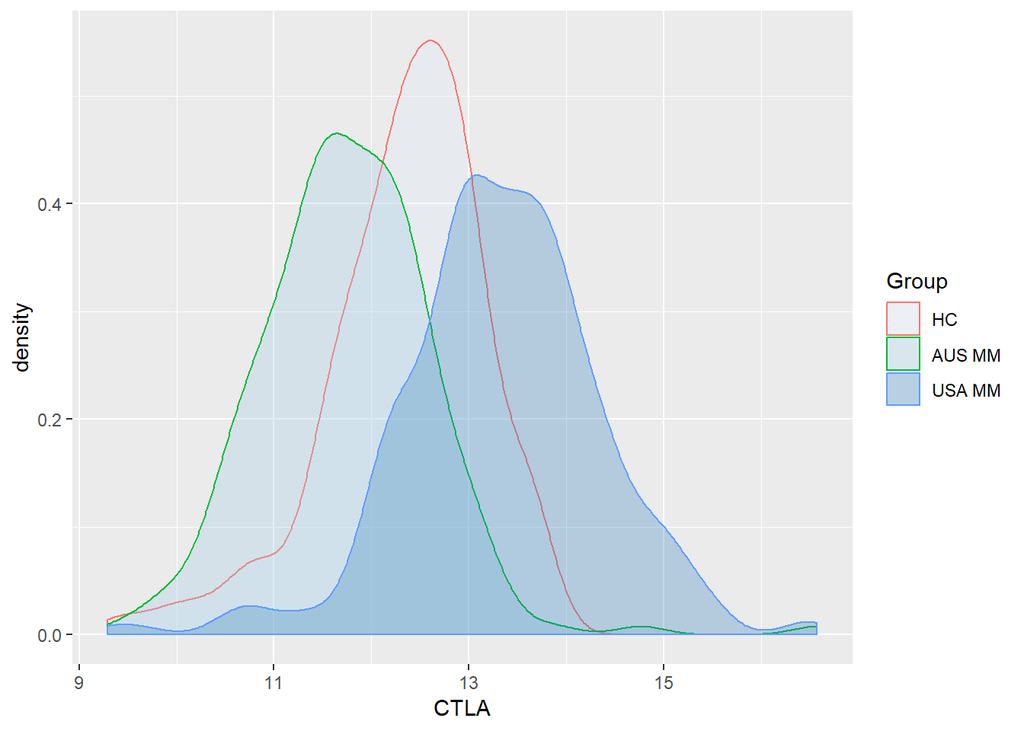

| Group | n | CTLA (mean) | CTLA (sd) |
| --- | --- | --- | --- |
| HC | 108 | 12.3 | 0.81 |
| AUS MM | 209 | 11.7 | 0.88 |
| USA MM | 273 | 13.3 | 1.01 |

Note:  
Mean and standard deviation of Australian healthy controls, Australian melanoma, and USA melanoma groups. The CTLA-4 distribution of the healthy controls lies between the two melanoma groups. All three groups are highly significantly different from each other. This implies that the melanoma groups are from different populations and should be analyzed seperately.

### **Comparing CTLA, age, gender, time to blood draw, breslow depth and ulceration between Australian and US melanoma patients.**

| USA | n | CTLA (mean) | Male (%) | Age (mean) | Ulceration (%) | Missing Ulc (%) | Breslow Depth (mean) | Missing Bres (%) | Time to Draw (mean) |
| --- | --- | --- | --- | --- | --- | --- | --- | --- | --- |
| 0 | 209 | 11.74 | 0.65 | 69.19 | 0.12 | 0.14 | 1.61 | 0.09 | 3.42 |
| 1 | 273 | 13.34 | 0.55 | 52.05 | 0.14 | 0.47 | 1.88 | 0.11 | 2.18 |

Note:  
US and Australia melanoma patients have significantly different CTLA-4 values and average ages. Ulceration is missing for 14% and 47% of Australian and US melanoma patients, respectively. Breslow depth is missing for 9% and 11% of Australian and US melanoma patients, respectively.

### **Comparing CTLA, age, gender, time to blood draw, breslow depth and ulceration between Australian and US melanoma patients within site on body of cancer.**

| USA | Site | n | CTLA (mean) | Male (%) | Age (mean) | Ulceration (%) | Missing Ulc (%) | Breslow Depth (mean) | Missing Bres (%) | Time to Draw (mean) |
| --- | --- | --- | --- | --- | --- | --- | --- | --- | --- | --- |
| 0 | Scalp/Neck | 18 | 11.52 | 0.89 | 74.44 | 0.17 | 0.11 | 4.33 | 0.06 | 3.28 |
| 0 | Face | 33 | 11.69 | 0.70 | 77.91 | 0.09 | 0.18 | 1.20 | 0.03 | 4.75 |
| 0 | Torso/Groin/Buttocks | 73 | 11.76 | 0.75 | 67.90 | 0.12 | 0.05 | 1.23 | 0.03 | 3.44 |
| 0 | Extremities | 59 | 11.66 | 0.47 | 68.27 | 0.15 | 0.15 | 1.79 | 0.07 | 3.46 |
| 0 | Unknown Primary | 8 | 11.95 | 0.75 | 61.62 | 0.00 | 1.00 | NaN | 1.00 | 3.40 |
| 0 | Not Specified | 18 | 12.19 | 0.39 | 59.50 | 0.11 | 0.06 | 0.64 | 0.11 | 0.90 |
| 1 | Scalp/Neck | 24 | 13.31 | 0.58 | 56.21 | 0.12 | 0.54 | 1.59 | 0.08 | 2.74 |
| 1 | Face | 39 | 13.28 | 0.64 | 57.85 | 0.15 | 0.49 | 1.82 | 0.05 | 2.47 |
| 1 | Torso/Groin/Buttocks | 105 | 13.36 | 0.65 | 50.27 | 0.15 | 0.43 | 2.03 | 0.03 | 2.14 |
| 1 | Extremities | 88 | 13.35 | 0.40 | 49.55 | 0.14 | 0.39 | 1.79 | 0.07 | 2.09 |
| 1 | Unknown Primary | 16 | 13.34 | 0.50 | 55.50 | 0.00 | 0.94 | NaN | 1.00 | 1.48 |
| 1 | Not Specified | 1 | 13.08 | 1.00 | 78.00 | 0.00 | 1.00 | NaN | 1.00 | 0.00 |

### **Comparing CTLA, age, gender, time to blood draw, breslow depth and ulceration between Australian and US melanoma patients within country and stage.**

| USA | Stage | n | CTLA (mean) | Male (%) | Age (mean) | Ulceration (%) | Missing Ulc (%) | Breslow Depth (mean) | Missing Bres (%) | Time to Draw (mean) |
| --- | --- | --- | --- | --- | --- | --- | --- | --- | --- | --- |
| 0 | 0 | 44 | 11.83 | 0.57 | 73.36 | 0.05 | 0.07 | 0.00 | 0.00 | 2.56 |
| 0 | 1 | 75 | 11.74 | 0.64 | 70.15 | 0.01 | 0.05 | 0.67 | 0.03 | 3.81 |
| 0 | 2 | 39 | 11.72 | 0.59 | 70.64 | 0.38 | 0.08 | 3.60 | 0.00 | 2.41 |
| 0 | 3 | 22 | 11.67 | 0.68 | 62.05 | 0.18 | 0.27 | 2.75 | 0.09 | 4.55 |
| 0 | 4 | 29 | 11.70 | 0.83 | 63.83 | 0.14 | 0.48 | 4.19 | 0.48 | 4.22 |
| 1 | 0 | 11 | 13.56 | 0.36 | 49.82 | 0.00 | 0.36 | 0.00 | 0.00 | 0.94 |
| 1 | 1 | 125 | 13.39 | 0.46 | 48.99 | 0.02 | 0.38 | 0.79 | 0.01 | 1.45 |
| 1 | 2 | 34 | 13.34 | 0.65 | 53.18 | 0.47 | 0.21 | 3.37 | 0.00 | 0.47 |
| 1 | 3 | 55 | 13.60 | 0.56 | 53.07 | 0.22 | 0.55 | 2.92 | 0.20 | 2.83 |
| 1 | 4 | 48 | 12.86 | 0.77 | 58.54 | 0.12 | 0.81 | 3.82 | 0.38 | 4.81 |

Note:  
Note the pattern in average age across stage comparing Australia and US.

### **Comparing CTLA, age, gender, time to blood draw, breslow depth and ulceration between Australian and US melanoma patients within country and Breslow missingness.**

| USA | missing.breslow | n | CTLA (mean) | Male (%) | Age (mean) | Ulceration (%) | Missing Ulc (%) | Breslow Depth (mean) | Time to Draw (mean) |
| --- | --- | --- | --- | --- | --- | --- | --- | --- | --- |
| 0 | 0 | 191 | 11.74 | 0.63 | 69.71 | 0.14 | 0.07 | 1.61 | 3.38 |
| 0 | 1 | 18 | 11.75 | 0.83 | 63.61 | 0.00 | 0.89 | NaN | 3.85 |
| 1 | 0 | 243 | 13.35 | 0.54 | 51.55 | 0.15 | 0.41 | 1.88 | 1.94 |
| 1 | 1 | 30 | 13.26 | 0.67 | 56.10 | 0.00 | 0.93 | NaN | 4.07 |

Note:  
AUS is coded as USA=0, missing.breslow is coded as missing value = 1.

### **Comparing CTLA, age, gender, time to blood draw, breslow depth and ulceration between Australian and US melanoma patients within country and Ulceration missingness.**

| USA | missing.ulc | n | CTLA (mean) | Male (%) | Age (mean) | Ulceration (%) | Breslow Depth (mean) | Missing Bres (%) | Time to Draw (mean) |
| --- | --- | --- | --- | --- | --- | --- | --- | --- | --- |
| 0 | 0 | 179 | 11.75 | 0.62 | 69.10 | 0.15 | 1.55 | 0.01 | 3.35 |
| 0 | 1 | 30 | 11.69 | 0.80 | 69.70 | 0.00 | 2.30 | 0.53 | 3.84 |
| 1 | 0 | 146 | 13.36 | 0.45 | 49.32 | 0.25 | 1.82 | 0.01 | 1.01 |
| 1 | 1 | 127 | 13.32 | 0.68 | 55.19 | 0.00 | 1.96 | 0.22 | 3.52 |

The difference in CTLA-4 expression level between the USA and Australia is significantly different. Excluding the higher CTLA-4 expression level from HC in the Australia population still results in a significant difference between the USA and Australia melanoma patients. Stratification by country isnt possible due to lack of American controls. Since there are no healthy controls from USA and USA CTLA-4 values are significantly higher, we should report the t-test between melanoma and HC in Australia and exclude the American melanoma patients. Performing a t-test on CTLA-4 expression level between healthy controls and melanoma patients is nonsensical due to the expression difference between countries.

### **CTLA-4 ~ Control + Age + Sex**

|  | Beta | 95% CI | p-value |
| --- | --- | --- | --- |
| Control = 1 | 0.43 | ( 0.19 , 0.68 ) | 6e-04 |

### *Aim 1: Does CTLA-4 level in blood differ between healthy controls and melanoma patients?*

Healthy controls have significantly higher CTLA-4 expression levels by 0.43 (95% CI 0.19-0.68, p=5.70e-04) than melanoma patients when controlling for age and sex.

Next, we will explore how the missingness relates to the other variables of concern.

### Contrast missingness Ulceration (Australia)

|  | n | CTLA (mean) | Male (%) | Age (mean) | Breslow Depth (mean) | Missing Bres (%) | Time to Draw (mean) |
| --- | --- | --- | --- | --- | --- | --- | --- |
| Non-missing | 179 | 11.75 | 0.62 | 69.1 | 1.55 | 0.01 | 3.35 |
| Missing | 30 | 11.69 | 0.80 | 69.7 | 2.30 | 0.53 | 3.84 |

### Contrast missingness Ulceration (USA)

|  | n | CTLA (mean) | Male (%) | Age (mean) | Breslow Depth (mean) | Missing Bres (%) | Time to Draw (mean) |
| --- | --- | --- | --- | --- | --- | --- | --- |
| Non-missing | 146 | 13.36 | 0.45 | 49.32 | 1.82 | 0.01 | 1.01 |
| Missing | 127 | 13.32 | 0.68 | 55.19 | 1.96 | 0.22 | 3.52 |

### Contrast missingness Breslow depth (Australia)

|  | n | CTLA (mean) | Male (%) | Age (mean) | Ulceration (%) | Missing Ulc (%) | Time to Draw (mean) |
| --- | --- | --- | --- | --- | --- | --- | --- |
| Non-missing | 191 | 11.74 | 0.63 | 69.71 | 26 | 0.07 | 3.38 |
| Missing | 18 | 11.75 | 0.83 | 63.61 | 0 | 0.89 | 3.85 |

### Contrast missingness Breslow depth (USA)

|  | n | CTLA (mean) | Male (%) | Age (mean) | Ulceration (%) | Missing Ulc (%) | Time to Draw (mean) |
| --- | --- | --- | --- | --- | --- | --- | --- |
| Non-missing | 243 | 13.35 | 0.54 | 51.55 | 37 | 0.41 | 1.94 |
| Missing | 30 | 13.26 | 0.67 | 56.10 | 0 | 0.93 | 4.07 |

### Is missingness associated with Stage?

|  | Beta | SE | p-value |
| --- | --- | --- | --- |
| Missing Ulceration ~ Stage (AUS) | 0.10 | 0.02 | <0.001 |
| Missing Breslow ~ Stage (AUS) | 0.10 | 0.01 | <0.001 |
| Missing Ulceration ~ Stage (USA) | 0.12 | 0.02 | <0.001 |
| Missing Breslow ~ Stage (USA) | 0.11 | 0.01 | <0.001 |

### **Summary of ulceration and breslow contrasts**

For Ulceration, the 157 missing values were compared to the 325 known observations. The missing data for Ulceration had higher average CTLA-4 expression (13.01) with a slightly lower standard deviation (1.18) contrasted with the observed average of 12.48 (sd=1.23). There were more males (70% vs. 54%), more Americans (81% vs. 45%), a longer average time to blood draw (3.58 yrs. vs. 2.30 yrs.), younger in average age (57.96 vs. 60.21), and a higher percentage of missing Breslow depth (28% vs. 1%) in the missing data when compared.

For Breslow depth, the 48 missing values were compared to the 434 known observations. The missing data for Ulceration had similar CTLA-4 expression (12.69) with similar standard deviation (1.30) contrasted with the observed average of 12.64 (sd=1.30). There were more males (73% vs. 58%), more Americans (62% vs. 56%), a longer average time to blood draw (3.99 yrs. vs. 2.58 yrs.), similar in average age (58.92 vs. 59.54), and a higher percentage of missing ulceration (92% vs. 26%) in the missing data when compared. Because missingness in ulceration and Breslow depth is associated with the explanatory variable, Stage, there is strong empirical evidence against MCAR.

### **MAR Assumption**

There is also a strong tendency for breslow depth and ulceration to not be reported for stages 3 and 4 and for patients with an unknown primary. According to AJCC staging, stages 3 and 4 classification are heavily determined by the detectable sizes of cancer cells at the sentinel node and the number of nodes affected. For ulceration and Breslow depth, the most probable reason for missingness of the $y_{unobserved}$ for ulcer status and skin depth of tumor is errors in reporting or data collections. Lack recording data properly doesn’t seem to be inherently related to the ulcer status or tumor size which would rule. However, the distribution of the missingness is significantly higher in higher stages and in certain sites such as those with an unknown primary. The dependency among other observed values variables implies a possible MAR assumption. Therefore, imputation of a standard controlling covariate will increase our effective sample size in the final analysis.

In order to test out the robustness of assumming an MAR missing mechanism, we will perform a sensitivity analysis. We will run different imputation techniques (MICE and KNN) and with various sets of auxiliary variables with which to perform the imputation. Our primary focus starts with multiple imputations with chained equations using the *mice* package. Auxillary variables with correlations above 0.05 and 0.20 to each incomplete variable will be used to impute missing values. The default method of imputation for Breslow depth and ulceration is predictive mean and logistic regression matching, respectively. Alternative methods robustly estimated the stage coefficient similarly. The results from the *mice* analysis were compared to an alternative imputation technique, k-nearest neighbors. Our final mice estimate were compared to the alternative imputation technique and the imputed values were evaluated for plausibilty.

We will impute the missing values separately for Australia and USA melanoma patients creating five datasets. The datasets are analyzed separately and beta coefficents and standard errors will be averaged across the analyzed sets to reduce bias. All the default methods for continous and binary auxillary variables were used in the imputation of the two main incomplete variables, Breslow depth and Ulceration.

Grouping Site into 2 levels (Unknown Primary & Unspecified vs rest) is optimal for both AUS and USA

### **Evaluate Censorship in AUS**

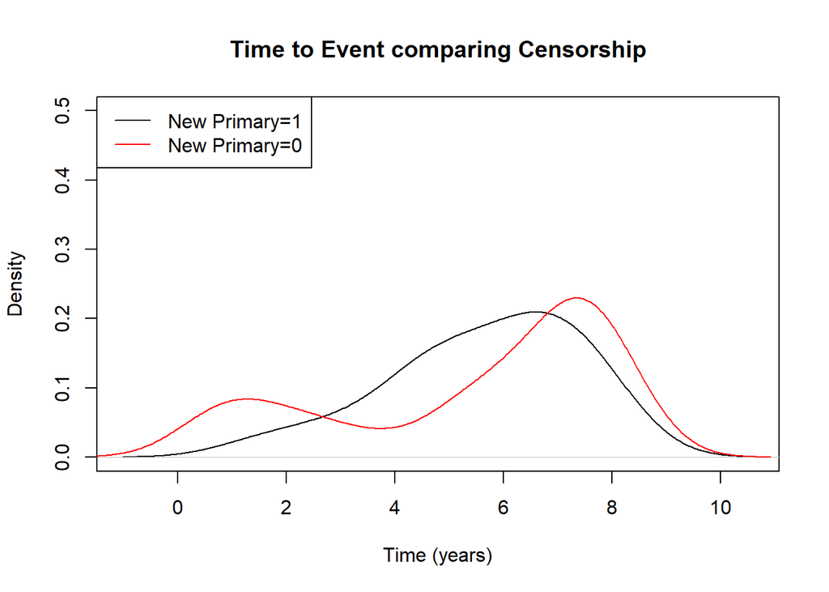

```
Proportion of censored events =  10 %
```

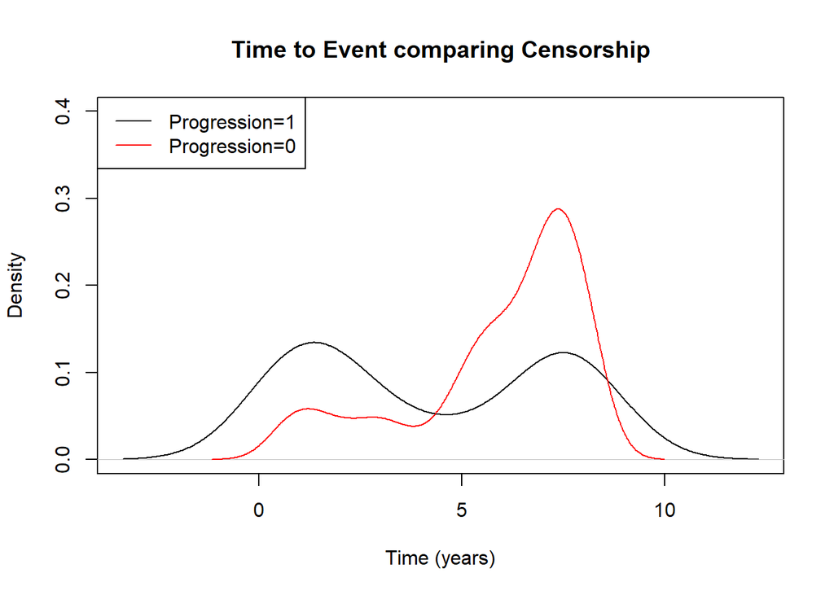

```
Proportion of censored events =  22 %
```

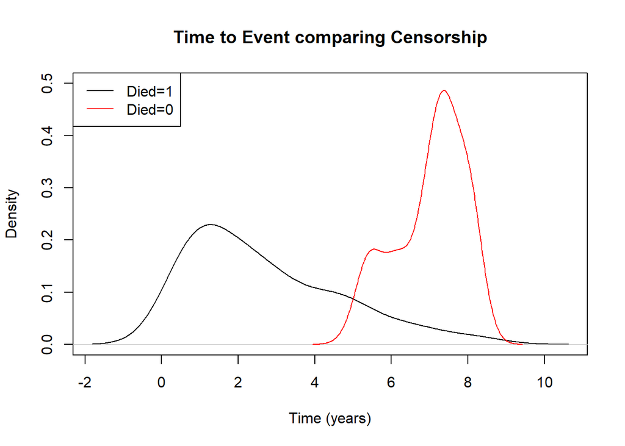

```
Proportion of censored events =  35 %
```

### **Evaluate Censorship in USA**

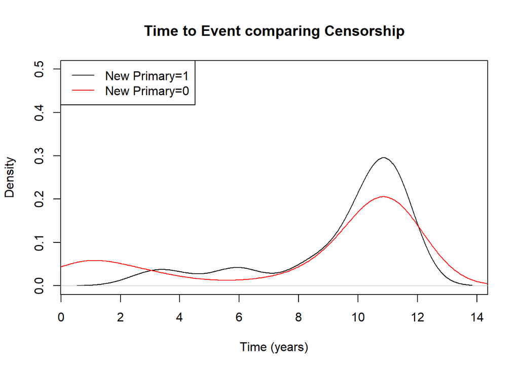

```
Proportion of censored events =  8 %
```

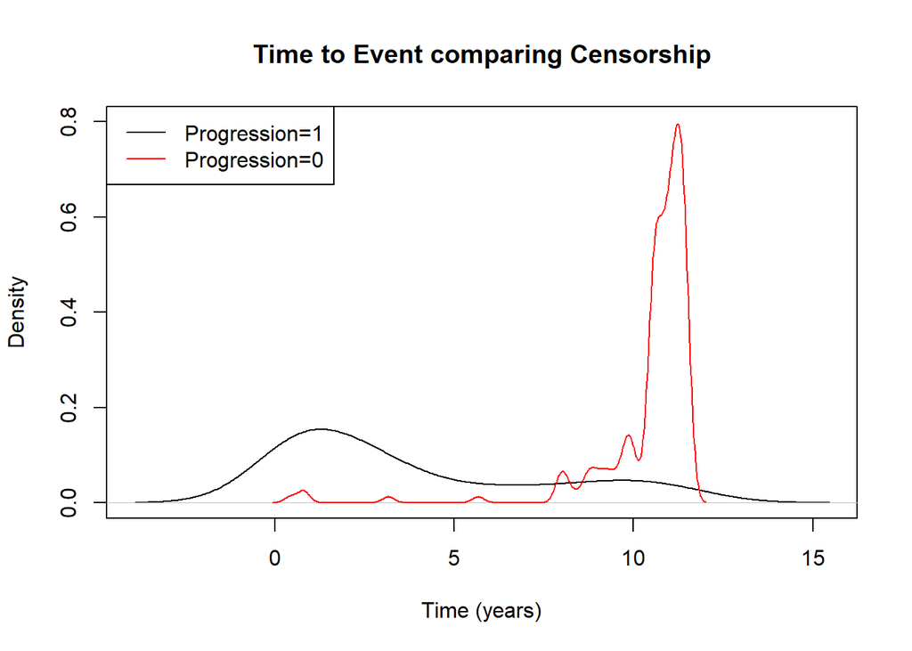

```
Proportion of censored events =  31 %
```

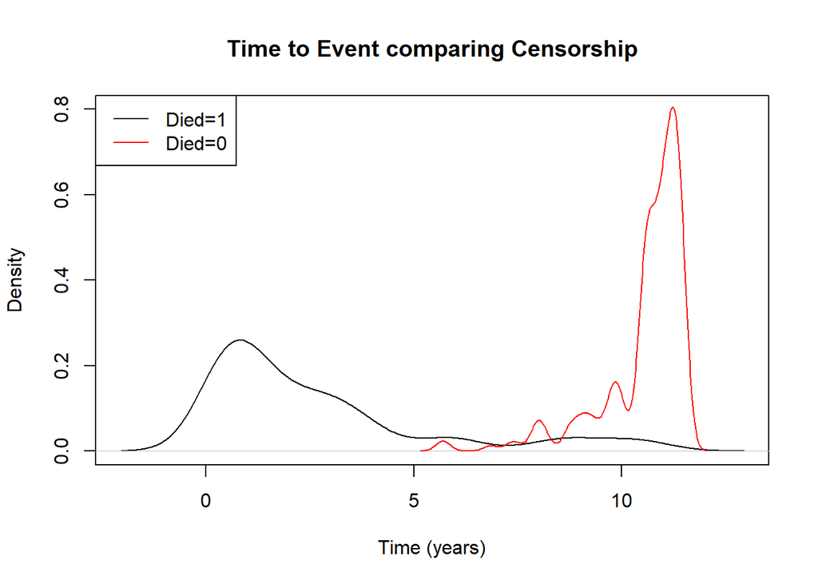

```
Proportion of censored events =  27 %
```

The proportion of censorship is relatively low and may cause bias in our estimator from a logistic regression model. Therefore, survival analysis was used to evaluate the outcomes - new primary, progression, and mortality.

### **Table 4**

### Compare Multiple Imputation by Chained Equations to K-Nearest Neighbor

|  | Beta | 95% CI | p |
| --- | --- | --- | --- |
| **AUS Stage (MICE)** |  |  |  |
| AUS Stage (continuous) Auxiliary Corr 0.05 | -0.20 | ( -0.34 , -0.06 ) | 0.005 |
| AUS Stage (continuous) Auxiliary Corr 0.20 | -0.19 | ( -0.33 , -0.05 ) | 0.008 |
| **AUS Stage (KNN)** |  |  |  |
| AUS Stage (KNN) | -0.19 | ( -0.32 , -0.06 ) | 0.005 |
| **AUS Stage 3-4 vs 0-2 (MICE)** |  |  |  |
| AUS Stage 3&4 vs 0-2 (MICE) | -0.47 | ( -0.85 , -0.09 ) | 0.016 |
| **AUS Stage 3-4 vs 0-2 (KNN)** |  |  |  |
| AUS Stage 3&4 vs 0-2 (KNN) | -0.45 | ( -0.82 , -0.08 ) | 0.018 |
| **AUS Stage 3-4 vs 1-2 vs 0 (MICE)** |  |  |  |
| AUS Stage 1&2 vs 0 (MICE) | -0.33 | ( -0.65 , 0 ) | 0.053 |
| AUS Stage 3&4 vs 0 (MICE) | -0.57 | ( -1.1 , -0.04 ) | 0.037 |
| **AUS Stage 3-4 vs 1-2 vs 0 (KNN)** |  |  |  |
| AUS Stage 1&2 vs 0 (KNN) | -0.33 | ( -0.66 , 0 ) | 0.048 |
| AUS Stage 3&4 vs 0 (KNN) | -0.56 | ( -1.09 , -0.03 ) | 0.038 |
| **USA Stage (MICE)** |  |  |  |
| USA Stage (continuous) Auxiliary Corr 0.05 | -0.17 | ( -0.32 , -0.02 ) | 0.030 |
| USA Stage (continuous) Auxiliary Corr 0.20 | -0.17 | ( -0.32 , -0.01 ) | 0.035 |
| **USA Stage (KNN)** |  |  |  |
| USA Stage (KNN) | -0.14 | ( -0.28 , 0 ) | 0.055 |
| **USA Stage 3-4 vs 0-2 (MICE)** |  |  |  |
| USA Stage 3&4 vs 0-2 (MICE) | -0.14 | ( -0.48 , 0.21 ) | 0.445 |
| **USA Stage 3-4 vs 0-2 (KNN)** |  |  |  |
| USA Stage 3&4 vs 0-2 (KNN) | -0.06 | ( -0.4 , 0.28 ) | 0.731 |
| **USA Stage 3-4 vs 1-2 vs 0 (MICE)** |  |  |  |
| USA Stage 1&2 vs 0 (MICE) | -0.22 | ( -0.84 , 0.4 ) | 0.485 |
| USA Stage 3&4 vs 0 (MICE) | -0.99 | ( -1.73 , -0.24 ) | 0.010 |
| **USA Stage 3-4 vs 1-2 vs 0 (KNN)** |  |  |  |
| USA Stage 1&2 vs 0 (KNN) | -0.22 | ( -0.84 , 0.4 ) | 0.494 |
| USA Stage 3&4 vs 0 (KNN) | -1.00 | ( -1.74 , -0.25 ) | 0.009 |

#### Auxiliary Variables Used to Impute Breslow Depth correlated above 0.05 for AUS

| x |
| --- |
| log2IL37U6 |
| Stage |
| Progression.AFTER |
| Age |
| Sex |
| Clarks.level |
| Ulceration |
| Other.Primary.AFTER |
| Other.NON.Skin.Cancer |
| Death.Melanoma.Related |
| Time2Draw |
| Blood.to.followup |
| Radiation.PRIOR.to.blood.draw |
| Radiation.AFTER.blood.draw |
| Any.Systemic.PRIOR.to.blood.draw |

#### Auxiliary Variables Used to Impute Breslow Depth correlated above 0.20 for AUS

| x |
| --- |
| Stage |
| Progression.AFTER |
| Clarks.level |
| Ulceration |
| Death.Melanoma.Related |
| Radiation.PRIOR.to.blood.draw |
| Any.Systemic.PRIOR.to.blood.draw |

#### Auxiliary Variables Used to Impute Ulceration correlated above 0.05 for AUS

| x |
| --- |
| log2IL37U6 |
| log2CTLA4GAPDH |
| Stage |
| Progression.AFTER |
| Sex |
| Breslow |
| Clarks.level |
| Other.Primary.AFTER |
| Other.NON.Skin.Cancer |
| Death.Melanoma.Related |
| Time2Draw |
| Radiation.PRIOR.to.blood.draw |
| Radiation.AFTER.blood.draw |
| Any.Systemic.PRIOR.to.blood.draw |

#### Auxiliary Variables Used to Impute Ulceration correlated above 0.20 for AUS

| x |
| --- |
| Stage |
| Progression.AFTER |
| Breslow |
| Clarks.level |
| Radiation.PRIOR.to.blood.draw |

#### Auxiliary Variables Used to Impute Breslow Depth correlated above 0.05 for USA

| x |
| --- |
| log2IL37U6 |
| log2CTLA4GAPDH |
| Stage |
| Progression.AFTER |
| Age |
| Sex |
| Clarks.level |
| Ulceration |
| Other.Primary.AFTER |
| Other.NON.Skin.Cancer |
| Death.Melanoma.Related |
| Time2Draw |
| mortality.after.blood.draw.10.year |
| Melanoma.specific.10.year.mortality.after.blood.draw |
| Blood.to.followup |
| Radiation.PRIOR.to.blood.draw |
| Radiation.AFTER.blood.draw |
| Any.Systemic.PRIOR.to.blood.draw |

#### Auxiliary Variables Used to Impute Breslow Depth correlated above 0.20 for USA

| x |
| --- |
| Stage |
| Progression.AFTER |
| Clarks.level |
| Ulceration |
| mortality.after.blood.draw.10.year |
| Melanoma.specific.10.year.mortality.after.blood.draw |
| Blood.to.followup |
| Any.Systemic.PRIOR.to.blood.draw |

#### Auxiliary Variables Used to Impute Ulceration correlated above 0.05 for USA

| x |
| --- |
| Stage |
| Progression.AFTER |
| Age |
| Sex |
| Breslow |
| Clarks.level |
| Other.Primary.AFTER |
| Other.NON.Skin.Cancer |
| Death.Melanoma.Related |
| Time2Draw |
| mortality.after.blood.draw.10.year |
| Melanoma.specific.10.year.mortality.after.blood.draw |
| Blood.to.followup |
| Radiation.PRIOR.to.blood.draw |
| Radiation.AFTER.blood.draw |
| Any.Systemic.PRIOR.to.blood.draw |

#### Auxiliary Variables Used to Impute Ulceration correlated above 0.20 for USA

| x |
| --- |
| Stage |
| Progression.AFTER |
| Age |
| Sex |
| Breslow |
| Clarks.level |
| Death.Melanoma.Related |
| Time2Draw |
| mortality.after.blood.draw.10.year |
| Melanoma.specific.10.year.mortality.after.blood.draw |
| Blood.to.followup |
| Radiation.PRIOR.to.blood.draw |
| Radiation.AFTER.blood.draw |
| Any.Systemic.PRIOR.to.blood.draw |